# An introduction to the SingleCellAlleleExperiment class

Jonas Schuck, Ahmad Al Ajami, Federico Marini and Katharina Imkeller

8 März 2024

#### Package

SingleCellAlleleExperiment 0.96.0

# 1 Introduction to the workflow

## 1.1 Biological background and motivation

Immune molecules such as B and T cell receptors, human leukocyte antigens (HLAs) or killer Ig-like receptors (KIRs) are encoded in the genetically most diverse loci of the human genome. Many of these immune genes are hyperpolymorphic, showing high allelic diversity across human populations. In addition, typical immune molecules are polygenic, which means that multiple functionally similar genes encode the same protein subunit.

However, interactive single-cell methods commonly used to analyze immune cells in large patient cohorts do not consider this. This leads to erroneous quantification of important immune mediators and impaired inter-donor comparability.

## 1.2 Workflow for unravelling the immunogenetic diversity in scData

We have developed a workflow, that allows quantification of expression and interactive exploration of donor-specific alleles of different immune genes. The workflow is divided into two software packages and one additional data package:

1. The **scIGD** software package consist of a *[Snakemake](https://snakemake.readthedocs.io/en/stable/)* workflow designed to automate and streamline the genotyping process for immune genes, focusing on key targets such as HLAs and KIRs, and enabling allele-specific quantification from single-cell RNA-sequencing (scRNA-seq) data using donor-specific references. For detailed information of the performed steps and how to utilize this workflow, please refer to its **[documentation](https://github.com/AGImkeller/scIGD)**.
2. To harness the full analytical potential of the results, we’ve developed a dedicated `R` package, `SingleCellAlleleExperiment` presented in this repository. This package provides a comprehensive multi-layer data structure, enabling the representation of immune genes at specific levels, including alleles, genes, and groups of functionally similar genes and thus, allows data analysis across these immonologically relevant, different layers of annotation.
3. The **scaeData** is an `R/ExperimentHub` data package providing datasets generated and processed by the **scIGD** software package which can be used to explore the data and potential downstream analysis workflows using the here presented novel `SingleCellAlleleExperiment` data structure. Refer to **scaeData** for more information regarding the available datasets and source of raw data.

This workflow is designed to support both **10x** and **BD Rhapsody** data, encompassing amplicon/targeted sequencing as well as whole-transcriptome-based data, providing flexibility to users working with different experimental setups.

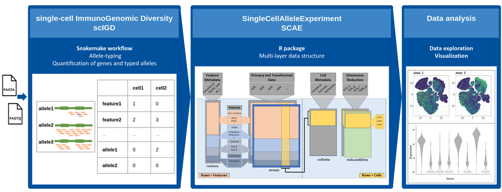

**Figure 1:** Overview of the scIGD workflow for unraveling immunogenomic diversity in single-cell data, highlighting the integration of the SingleCellAlleleExperiment package for comprehensive data analysis.

# 2 Introduction to the `SingleCellAlleleExperiment (SCAE)` class

The `SingleCellAlleleExperiment (SCAE)` class serves as a comprehensive multi-layer data structure, enabling the representation of immune genes at specific levels, including alleles, genes, and groups of functionally similar genes and thus, allows data analysis across these immonologically relevant, different layers of annotation. The implemented data object is derived from the *[SingleCellExperiment (SCE)](https://bioconductor.org/packages/release/bioc/html/SingleCellExperiment.html)* class and follows similar conventions, where rows should represent features (genes, transcripts) and columns should represent cells.

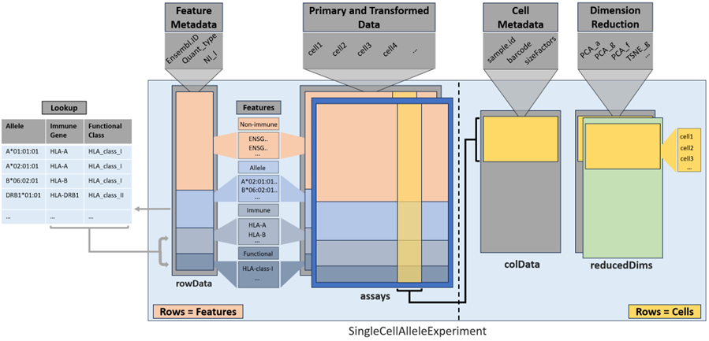

**Figure 2:** Scheme of SingleCellAlleleExperiment object structure with lookup table.

For the integration of the relevant additional data layers (see **Figure 2**), the quantification data for alleles, generated by the novel **scIGD** software package, is aggregated into two additional data layers via an ontology-based design principle using a lookup table during object generation.

For example, the counts of the alleles `A*01:01:01:01` and `A*02:01:01:01` that are present in the raw input data will be combined into the `HLA-A` immune gene layer (see **Table 1** below). Next, all counts of imune genes corresponding to `HLA-class I` are combined into the `HLA-class I` functional class layer. See the structure of the used lookup table below.

**Table 1:** Scheme of the lookup table used to aggregate allele information into multiple data layers.

[output not shown]

The resulting `SCAE` data object can be used in combination with established single cell analysis packages like *[scater](https://bioconductor.org/packages/release/bioc/html/scater.html)* and *[scran](https://bioconductor.org/packages/release/bioc/html/scran.html)* to perform downstream analysis on immune gene expression, allowing data exploration on functional and allele level. See the vignette for furthter information and insights on how to perform downstream analysis using exemplary data from the accompanying `R/Experimenthub` package **scaeData**.

## 2.1 Expected input and dataset description

The read in function of the SCAE package `read_allele_counts()` expects specific files that are generated by the previous steps of the workflow, performed in the **scIGD** package. One input parameter needs to state the path to a directory containing all the input files. The file identifiers can be specifically stated as parameters. The default file identifiers, as they are outputted from **scIGD** are listed below: The stated input directory should contain the following files:

- **cells_x_genes.barcodes.txt** (list of barcodes/cell identifiers)
- **cells_x_genes.features.txt** (list of feature identifiers)
- **cells_x_genes_mtx.mtx** (Contains the quantification matrix)
- **lookup_table.csv** (Info for generating multiple data layers)

The dataset used for the here shown downstream analysis is taken from the accompanying data package **scaeData**. Specifically we are using the `pbmc_5k` dataset. Find more information about the data, including the source of the raw data here: **scaeData**.

# 3 Exemplary downstream analysis

## 3.1 Loading packages

The following packages are abundant for performing the here stated downstream analysis and visualization.

```r
library(SingleCellAlleleExperiment)
library(scaeData)
library(scater)
```

## 3.2 Reading in data and performing quality check

### 3.2.1 Stating input directory containing the expected files

Download and save the **“pbmc_5k”** dataset from the accompanying `ExperimentHub/scaeData` package.

```r
example_data_5k <- scaeData::scaeDataGet(dataset = "pbmc_5k")
```

```
## Retrieving barcode identifiers for **pbmc 5k** dataset...DONE
```

```
## Retrieving feature identifiers for **pbmc 5k** dataset...DONE
```

```
## Retrieving quantification matrix for **pbmc 5k** dataset...DONE
```

```r
example_data_5k
```

```
## $dir
## [1] "/home/jonas/.cache/R/ExperimentHub/"
##
## $barcodes
## [1] "2271835753e28_9519"
##
## $features
## [1] "2271871ae76a9_9520"
##
## $matrix
## [1] "227183f702695_9521"
```

The return value of the `scaeDataGet()` function is a list containing four elements. The `$dir` slot contains the directory where the files downloaded from `ExperimentHub` are saved on your device. The remaining three slots `$barcodes`, `$features`, `$matrix` contain the corresponding file names (named by ExperimentHub). The list is then used to pass the saved information to the related parameters of the `read_allele_counts()` function of the here presented package. See next section.

### 3.2.2 Generate SingleCellAlleleExperiment object

This is an essential step. The read in function `read_allele_counts()` is the function you use to read in your data and to generate a `SCAE` object.

#### 3.2.2.1 Read in parameters

If you used the **scIGD** package to generate your input files **(RECOMMENDED AND EXPECTED)**, then state the path containing all expected files to the `sample_dir` parameter in the `read_allele_counts()` function. In case you renamed the files, specify the new file identifiers in the corresponding parameters `lookup_file`, `barcode_file`, `gene_file`, `matrix_file`, otherwise leave it to the stated default values.

The `read_allele_counts()` function also provides multiple parameters to perform filtering steps on the cells contained in your data. For this, **multiple parameter combinations are possible and showcased below.** Filtering is performed on a [**knee plot**](https://liorpachter.wordpress.com/tag/knee-plot/).

The first parameter, where you state which **filter mode** you want to use, gives the following valid options: `filter = c("yes", "no", "custom")`.

- `filter = "no"`: Shows a knee plot for determining a potential threshold for filtering by yourself. **No SCAE object will be generated**.
- `filter = "yes"` : Automatically filters the cells on the inflection point of the computed knee plot and generates a SCAE object.
- `filter = "custom"` : The user can give a custom threshold for manually filtering cells, which is different than the automatically computed one in `filter = "yes"`. State your custom threshold as an integer in the `filter_threshold` parameter.

Additionally, the `verbose` parameter gives you an option to toggle runtime-information for the different steps during object generation. Messages regarding the filtering process (suggested inflection point threshold) will not be toggled off if `verbose = FALSE`.

**Exemplary read in using all described filter-modes generating a SCAE object are shown in the following code-chunks:**

#### 3.2.2.2 `filter = "no"`

Only show the knee plot without generating a SCAE object. All function parameters are shown. Information messages (`verbose = FALSE`) are turned off.

```r
scae <- read_allele_counts(example_data_5k$dir,
                           sample_names = "example_data",
                           filter = "no",
                           lookup_file = "lookup_table_HLA_only.csv",
                           barcode_file = example_data_5k$barcodes,
                           gene_file = example_data_5k$features,
                           matrix_file = example_data_5k$matrix,
                           filter_threshold = NULL,
                           example_dataset = TRUE,
                           verbose = FALSE)
```

```
## Suggested threshold based on inflection point is at: 282 UMI counts.
```

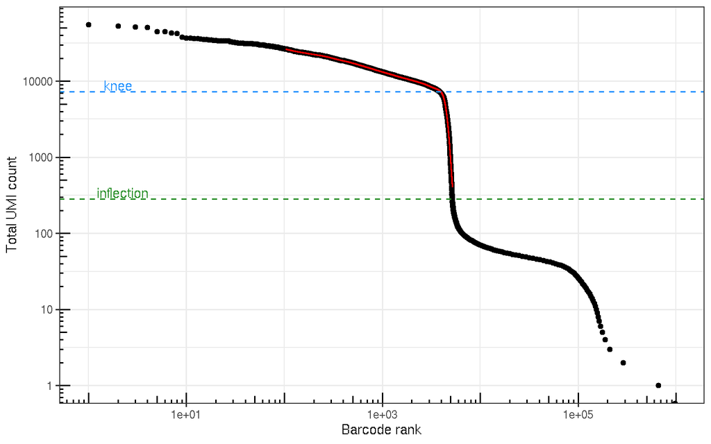

#### 3.2.2.3 `filter = "yes"`

Automatic filtering mode and generation of a SCAE object. Filtering is performed on the computed inflection point of the knee plot.

```r
scae <- read_allele_counts(example_data_5k$dir,
                           sample_names = "example_data",
                           filter = "yes",
                           lookup_file = "lookup_table_HLA_only.csv",
                           barcode_file = example_data_5k$barcodes,
                           gene_file = example_data_5k$features,
                           matrix_file = example_data_5k$matrix,
                           filter_threshold = NULL,
                           example_dataset = TRUE,
                           verbose = TRUE)
```

```
## Filtering performed based on the inflection point at: 282 UMI counts.
```

```
## Runtime check (1/2) Read_in: 29.5 seconds
```

```
## Using org.Hs to retrieve NCBI gene identifiers.
```

```
##      Generating SCAE (1/5) extending rowData: 5.72 seconds
```

```
##      Generating SCAE (2/5) filtering and normalization: 0.95 seconds
```

```
##      Generating SCAE (3/5) alleles2genes: 2.41 seconds
```

```
##      Generating SCAE (4/5) genes2functional: 3.17 seconds
```

[output not shown]

```
## Runtime check (2/2) Generating SCAE completed: 15.56 seconds
```

```
## Total runtime, completed read_in, filtering and normalization and generating scae object 46 seconds
```

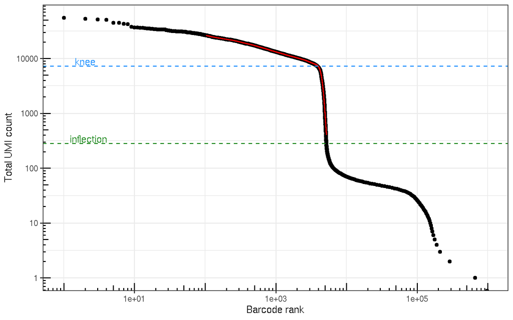

```r
scae
```

```
## class: SingleCellAlleleExperiment
## dim: 62762 5199
## metadata(0):
## assays(2): counts logcounts
## rownames(62762): ENSG00000279928.2 ENSG00000228037.1 ... HLA_class_I
##   HLA_class_II
## rowData names(4): Ensembl_ID Symbol NI_I Quant_type
## colnames(5199): AAACCCAAGCGTATGG AAACCCAGTCCTACAA ... TTTGTTGTCCTTGGAA
##   TTTGTTGTCGCACGAC
## colData names(3): Sample Barcode sizeFactor
## reducedDimNames(0):
## mainExpName: NULL
## altExpNames(0):
```

#### 3.2.2.4 `filter = "custom"`

Custom filtering mode and generation of a SCAE object. Filtering performed on the threshold stated in the `filter_threshold` parameter.

```r
#this is the object used in the further workflow
scae <- read_allele_counts(example_data_5k$dir,
                           sample_names = "example_data",
                           filter = "custom",
                           lookup_file = "lookup_table_HLA_only.csv",
                           barcode_file = example_data_5k$barcodes,
                           gene_file = example_data_5k$features,
                           matrix_file = example_data_5k$matrix,
                           filter_threshold = 282,
                           example_dataset = TRUE)
scae
```

```
## class: SingleCellAlleleExperiment
## dim: 62762 5199
## metadata(0):
## assays(2): counts logcounts
## rownames(62762): ENSG00000279928.2 ENSG00000228037.1 ... HLA_class_I
##   HLA_class_II
## rowData names(4): Ensembl_ID Symbol NI_I Quant_type
## colnames(5199): AAACCCAAGCGTATGG AAACCCAGTCCTACAA ... TTTGTTGTCCTTGGAA
##   TTTGTTGTCGCACGAC
## colData names(3): Sample Barcode sizeFactor
## reducedDimNames(0):
## mainExpName: NULL
## altExpNames(0):
```

### 3.2.3 Showcasing different object slots

#### 3.2.3.1 RowData slot

Two new classification columns are introduced in the `rowData` slot. Namely the `NI_I` column (classification of each row as `NI = non_immune` or `I = immune`) and `Quant_type` column (classification of each row to which data layer it is corresponding to). Both columns are used jointly to identify each row of the object to its corresponding data layer (see **figure 1**).

```r
rowData(scae)
```

```
## DataFrame with 62762 rows and 4 columns
##                            Ensembl_ID       Symbol        NI_I  Quant_type
##                           <character>  <character> <character> <character>
## ENSG00000279928.2   ENSG00000279928.2           NA          NI           G
## ENSG00000228037.1   ENSG00000228037.1 LOC100996583          NI           G
## ENSG00000142611.17 ENSG00000142611.17       PRDM16          NI           G
## ENSG00000284616.1   ENSG00000284616.1           NA          NI           G
## ENSG00000157911.11 ENSG00000157911.11        PEX10          NI           G
## ...                               ...          ...         ...         ...
## HLA-B                           HLA-B        HLA-B           I           G
## HLA-C                           HLA-C        HLA-C           I           G
## HLA-DRB1                     HLA-DRB1     HLA-DRB1           I           G
## HLA_class_I               HLA_class_I  HLA_class_I           I           F
## HLA_class_II             HLA_class_II HLA_class_II           I           F
```

#### 3.2.3.2 ColData slot

As the object extends the count matrix during the object generation, its abundant to compute scaling factors on the raw data prior to extending and integrating the data layers. The scaling factors are used for scaling normalization in a later step of the SCAE constructor.

```r
colData(scae)
```

```
## DataFrame with 5199 rows and 3 columns
##                        Sample          Barcode sizeFactor
##                   <character>      <character>  <numeric>
## AAACCCAAGCGTATGG example_data AAACCCAAGCGTATGG   1.639967
## AAACCCAGTCCTACAA example_data AAACCCAGTCCTACAA   1.493352
## AAACCCATCACCTCAC example_data AAACCCATCACCTCAC   0.144215
## AAACGCTAGGGCATGT example_data AAACGCTAGGGCATGT   0.731275
## AAACGCTGTAGGTACG example_data AAACGCTGTAGGTACG   1.596363
## ...                       ...              ...        ...
## TTTGTTGCAGGTACGA example_data TTTGTTGCAGGTACGA   0.983300
## TTTGTTGCAGTCTCTC example_data TTTGTTGCAGTCTCTC   1.160318
## TTTGTTGGTAATTAGG example_data TTTGTTGGTAATTAGG   0.384139
## TTTGTTGTCCTTGGAA example_data TTTGTTGTCCTTGGAA   0.696771
## TTTGTTGTCGCACGAC example_data TTTGTTGTCGCACGAC   0.903892
```

### 3.2.4 Utilize layer specific `getter-functions()`

Additionally to the established `getters` from the SCE package, new getters are implemented to retrieve the different data layers integrated in the SCAE object.

#### 3.2.4.1 Non-immune genes

```r
scae_nonimmune_subset <- scae_subset(scae, "nonimmune")

head(rownames(scae_nonimmune_subset))
```

```
## [1] "ENSG00000279928.2"  "ENSG00000228037.1"  "ENSG00000142611.17"
## [4] "ENSG00000284616.1"  "ENSG00000157911.11" "ENSG00000269896.2"
```

#### 3.2.4.2 Alleles

```r
scae_alleles_subset <- scae_subset(scae, "alleles")

head(rownames(scae_alleles_subset))
```

```
## [1] "A*02:01:01:01" "A*29:02:01:01" "B*18:01:01:01" "B*51:01:01"
## [5] "C*01:02:01"    "C*05:01:01:01"
```

#### 3.2.4.3 Immune genes

```r
scae_immune_genes_subset <- scae_subset(scae, "immune_genes")

head(rownames(scae_immune_genes_subset))
```

```
## [1] "HLA-A"    "HLA-B"    "HLA-C"    "HLA-DRB1"
```

#### 3.2.4.4 Functional gene group

```r
scae_functional_groups_subset <- scae_subset(scae, "functional_groups")

head(rownames(scae_functional_groups_subset))
```

```
## [1] "HLA_class_I"  "HLA_class_II"
```

## 3.3 Expression evaluation

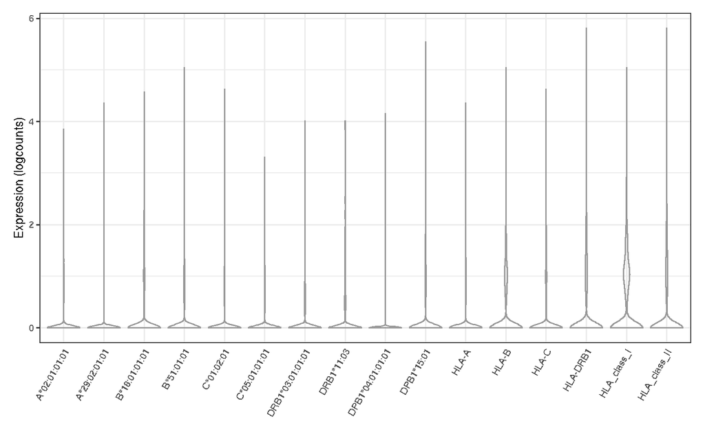

```r
scae_immune_layers_subset <- c(rownames(scae_subset(scae, "alleles")),
                               rownames(scae_subset(scae, "immune_genes")),
                               rownames(scae_subset(scae, "functional_groups")))

scater::plotExpression(scae, scae_immune_layers_subset)
```

# 4 Additional

As the SCAE object is extending the SCE object, it is also compatible with the *iSEE* package for interactive data exploration.

```
## R Under development (unstable) (2024-02-26 r85990)
## Platform: x86_64-pc-linux-gnu
## Running under: Ubuntu 22.04.3 LTS
##
## Matrix products: default
## BLAS:   /usr/lib/x86_64-linux-gnu/blas/libblas.so.3.10.0
## LAPACK: /usr/lib/x86_64-linux-gnu/lapack/liblapack.so.3.10.0
##
## locale:
##  [1] LC_CTYPE=en_US.UTF-8       LC_NUMERIC=C
##  [3] LC_TIME=de_DE.UTF-8        LC_COLLATE=en_US.UTF-8
##  [5] LC_MONETARY=de_DE.UTF-8    LC_MESSAGES=en_US.UTF-8
##  [7] LC_PAPER=de_DE.UTF-8       LC_NAME=C
##  [9] LC_ADDRESS=C               LC_TELEPHONE=C
## [11] LC_MEASUREMENT=de_DE.UTF-8 LC_IDENTIFICATION=C
```

[output cut: 77 more lines]